# R Notebook sandbox: Playing with Hierarchical Clustering

# 1 Hierarchical Clustering

We are now going to apply distance to aggregate multivariate data. Recall that typically we refer to a data frame based on its rows and columns. Generally, the rows represent observations and the columns represent features.

As we try to aggregate data, we need to ask: are we aggregating the rows or the columns? Why? So let’s look at an example.

## 1.1 Data `protein`

http://www.dm.unibo.it/~simoncin/Protein.html

The following data, originated by A. Weber and cited in Hand et al. (1994, pp. 297), measure the amount of protein consumed for nine food groups in 25 European countries. The nine food groups are red meat (RedMeat), white meat (WhiteMeat), eggs (Eggs), milk (Milk), fish (Fish), cereal (Cereal), starch (Starch), nuts (Nuts), and fruits and vegetables (FruitVeg). Suppose you want to determine whether national figures in protein consumption can be used to determine certain types or categories of countries; specifically, you want to perform a cluster analysis to determine whether these 25 countries can be formed into groups suggested by the data.

- Reference: Weber, A. (1973) Agrarpolitik im Spannungsfeld der internationalen Ernaehrungspolitik, Institut fuer Agrarpolitik und marktlehre, Kiel. Also found in: Gabriel, K.R. (1981) Biplot display of multivariate matrices for inspection of data and diagnosis. In Interpreting Multivariate Data (Ed. V. Barnett), New York: John Wiley & Sons, 147-173.
- Hand, D.J., et al. (1994) A Handbook of Small Data Sets, London: Chapman & Hall, 297-298.

```r
library(humanVerseWSU);
# You need R tools for this to work:  https://cran.r-project.org/bin/windows/Rtools/
# You may want to see if you have the latest version...
# library(devtools);
# detach(package:humanVerseWSU);
# install_github("MonteShaffer/humanVerseWSU/humanVerseWSU");
# Choose (3) None to minimize headaches ....
# library(humanVerseWSU);

example.datasets.path = "C:/Users/Alexander Nevsky/Dropbox/WSU-419/Fall 2020/__student_access__/sample_latex_files/Multivariate-2009/datasets/";

# https://www.codebus.net/d-2oZ.html
protein.file = paste0(example.datasets.path,"protein.txt");
protein = read.table(protein.file);
row = protein[1,];

colnames(protein) = row;
protein = protein[-c(1),];

protein;
```

|  | Country | RedMeat | WhiteMeat | Eggs | Milk | Fish | Cereals | Starch | Nuts | Fr&Veg |
| --- | --- | --- | --- | --- | --- | --- | --- | --- | --- | --- |
| 2 | Albania | 10.1 | 1.4 | 0.5 | 8.9 | 0.2 | 42.3 | 0.6 | 5.5 | 1.7 |
| 3 | Austria | 8.9 | 14.0 | 4.3 | 19.9 | 2.1 | 28.0 | 3.6 | 1.3 | 4.3 |
| 4 | Belgium | 13.5 | 9.3 | 4.1 | 17.5 | 4.5 | 26.6 | 5.7 | 2.1 | 4.0 |
| 5 | Bulgaria | 7.8 | 6.0 | 1.6 | 8.3 | 1.2 | 56.7 | 1.1 | 3.7 | 4.2 |
| 6 | Czechoslovakia | 9.7 | 11.4 | 2.8 | 12.5 | 2.0 | 34.3 | 5.0 | 1.1 | 4.0 |
| 7 | Denmark | 10.6 | 10.8 | 3.7 | 25.0 | 9.9 | 21.9 | 4.8 | 0.7 | 2.4 |
| 8 | E.Germany | 8.4 | 11.6 | 3.7 | 11.1 | 5.4 | 24.6 | 6.5 | 0.8 | 3.6 |
| 9 | Finland | 9.5 | 4.9 | 2.7 | 33.7 | 5.8 | 26.3 | 5.1 | 1.0 | 1.4 |
| 10 | France | 18.0 | 9.9 | 3.3 | 19.5 | 5.7 | 28.1 | 4.8 | 2.4 | 6.5 |
| 11 | Greece | 10.2 | 3.0 | 2.8 | 17.6 | 5.9 | 41.7 | 2.2 | 7.8 | 6.5 |

[output cut: 15 more lines]

```r
# why would I do this?
protein.file2 = paste0(example.datasets.path,"pipe-format/protein.txt");
write.table( protein , file=protein.file2, quote=FALSE, col.names=TRUE, row.names=FALSE, sep="|");
protein = read.csv(protein.file2, header=TRUE, quote="", sep="|");
protein;
```

| Country | RedMeat | WhiteMeat | Eggs | Milk | Fish | Cereals | Starch | Nuts | Fr.Veg |
| --- | --- | --- | --- | --- | --- | --- | --- | --- | --- |
| Albania | 10.1 | 1.4 | 0.5 | 8.9 | 0.2 | 42.3 | 0.6 | 5.5 | 1.7 |
| Austria | 8.9 | 14.0 | 4.3 | 19.9 | 2.1 | 28.0 | 3.6 | 1.3 | 4.3 |
| Belgium | 13.5 | 9.3 | 4.1 | 17.5 | 4.5 | 26.6 | 5.7 | 2.1 | 4.0 |
| Bulgaria | 7.8 | 6.0 | 1.6 | 8.3 | 1.2 | 56.7 | 1.1 | 3.7 | 4.2 |
| Czechoslovakia | 9.7 | 11.4 | 2.8 | 12.5 | 2.0 | 34.3 | 5.0 | 1.1 | 4.0 |
| Denmark | 10.6 | 10.8 | 3.7 | 25.0 | 9.9 | 21.9 | 4.8 | 0.7 | 2.4 |
| E.Germany | 8.4 | 11.6 | 3.7 | 11.1 | 5.4 | 24.6 | 6.5 | 0.8 | 3.6 |
| Finland | 9.5 | 4.9 | 2.7 | 33.7 | 5.8 | 26.3 | 5.1 | 1.0 | 1.4 |
| France | 18.0 | 9.9 | 3.3 | 19.5 | 5.7 | 28.1 | 4.8 | 2.4 | 6.5 |
| Greece | 10.2 | 3.0 | 2.8 | 17.6 | 5.9 | 41.7 | 2.2 | 7.8 | 6.5 |

[output cut: 15 more lines]

```r
round( dist( removeColumnsFromDataFrame(protein,"Country") ), digits=2);
```

```
##        1     2     3     4     5     6     7     8     9    10    11    12
## 2  23.18
## 3  21.65  7.87
## 4  15.69 32.30 32.79
## 5  15.15 10.31 10.61 24.01
## 6  30.16 11.96 11.12 40.33 19.42
## 7  22.87 10.74  8.93 33.61 10.61 15.18
## 8  30.99 17.42 17.60 40.34 24.02 12.25 23.83
## 9  23.17 11.01  6.01 33.26 13.44 12.72 13.86 18.18
## 10 12.14 19.53 18.25 19.32 15.03 24.47 22.11 24.11 18.25
## 11 13.16 16.97 18.78 18.40  9.18 26.73 17.52 29.98 21.26 14.93
## 12 27.90 10.04  9.15 38.36 17.58  8.94 16.18 11.57 10.15 22.98 25.02
## 13 10.62 14.69 13.57 21.01  8.71 21.60 15.62 23.76 15.16  7.98 10.70 20.04
## 14 28.30  6.76  9.68 38.53 16.35  8.36 13.27 14.68 12.35 24.06 23.21  6.83
## 15 26.81 13.68 10.80 38.17 18.73  6.69 14.99 11.69 13.15 21.42 25.67 10.88
```

[output cut: 35 more lines]

```r
round( cor( removeColumnsFromDataFrame(protein,"Country") ), digits=2);
```

```
##           RedMeat WhiteMeat  Eggs  Milk  Fish Cereals Starch  Nuts Fr.Veg
## RedMeat      1.00      0.15  0.59  0.50  0.06   -0.50   0.14 -0.35  -0.07
## WhiteMeat    0.15      1.00  0.62  0.28 -0.23   -0.41   0.31 -0.63  -0.06
## Eggs         0.59      0.62  1.00  0.58  0.07   -0.71   0.45 -0.56  -0.05
## Milk         0.50      0.28  0.58  1.00  0.14   -0.59   0.22 -0.62  -0.41
## Fish         0.06     -0.23  0.07  0.14  1.00   -0.52   0.40 -0.15   0.27
## Cereals     -0.50     -0.41 -0.71 -0.59 -0.52    1.00  -0.53  0.65   0.05
## Starch       0.14      0.31  0.45  0.22  0.40   -0.53   1.00 -0.47   0.08
## Nuts        -0.35     -0.63 -0.56 -0.62 -0.15    0.65  -0.47  1.00   0.37
## Fr.Veg      -0.07     -0.06 -0.05 -0.41  0.27    0.05   0.08  0.37   1.00
```

### 1.1.1 Should we take the transpose?

So what do we want to aggregate? Countries? Or foods? We can do either.

```r
cols = colnames(protein);
rows = protein$Country;

df = removeColumnsFromDataFrame(protein,"Country");
df.t = transposeMatrix(df);
colnames(df.t) = rows;

protein.t = as.data.frame(df.t);
protein.t;
```

|  | Albania | Austria | Belgium | Bulgaria | Czechoslovakia | Denmark | E.Germany | Finland | France | Greece | Hungary | Ireland | Italy | Netherlands | Norway | Poland | Portugal | Romania | Spain | Sweden | Switzerland | UK | USSR | W.Germany | Yugoslavia |
| --- | --- | --- | --- | --- | --- | --- | --- | --- | --- | --- | --- | --- | --- | --- | --- | --- | --- | --- | --- | --- | --- | --- | --- | --- | --- |
| RedMeat | 10.1 | 8.9 | 13.5 | 7.8 | 9.7 | 10.6 | 8.4 | 9.5 | 18.0 | 10.2 | 5.3 | 13.9 | 9.0 | 9.5 | 9.4 | 6.9 | 6.2 | 6.2 | 7.1 | 9.9 | 13.1 | 17.4 | 9.3 | 11.4 | 4.4 |
| WhiteMeat | 1.4 | 14.0 | 9.3 | 6.0 | 11.4 | 10.8 | 11.6 | 4.9 | 9.9 | 3.0 | 12.4 | 10.0 | 5.1 | 13.6 | 4.7 | 10.2 | 3.7 | 6.3 | 3.4 | 7.8 | 10.1 | 5.7 | 4.6 | 12.5 | 5.0 |
| Eggs | 0.5 | 4.3 | 4.1 | 1.6 | 2.8 | 3.7 | 3.7 | 2.7 | 3.3 | 2.8 | 2.9 | 4.7 | 2.9 | 3.6 | 2.7 | 2.7 | 1.1 | 1.5 | 3.1 | 3.5 | 3.1 | 4.7 | 2.1 | 4.1 | 1.2 |
| Milk | 8.9 | 19.9 | 17.5 | 8.3 | 12.5 | 25.0 | 11.1 | 33.7 | 19.5 | 17.6 | 9.7 | 25.8 | 13.7 | 23.4 | 23.3 | 19.3 | 4.9 | 11.1 | 8.6 | 24.7 | 23.8 | 20.6 | 16.6 | 18.8 | 9.5 |
| Fish | 0.2 | 2.1 | 4.5 | 1.2 | 2.0 | 9.9 | 5.4 | 5.8 | 5.7 | 5.9 | 0.3 | 2.2 | 3.4 | 2.5 | 9.7 | 3.0 | 14.2 | 1.0 | 7.0 | 7.5 | 2.3 | 4.3 | 3.0 | 3.4 | 0.6 |
| Cereals | 42.3 | 28.0 | 26.6 | 56.7 | 34.3 | 21.9 | 24.6 | 26.3 | 28.1 | 41.7 | 40.1 | 24.0 | 36.8 | 22.4 | 23.0 | 36.1 | 27.0 | 49.6 | 29.2 | 19.5 | 25.6 | 24.3 | 43.6 | 18.6 | 55.9 |
| Starch | 0.6 | 3.6 | 5.7 | 1.1 | 5.0 | 4.8 | 6.5 | 5.1 | 4.8 | 2.2 | 4.0 | 6.2 | 2.1 | 4.2 | 4.6 | 5.9 | 5.9 | 3.1 | 5.7 | 3.7 | 2.8 | 4.7 | 6.4 | 5.2 | 3.0 |
| Nuts | 5.5 | 1.3 | 2.1 | 3.7 | 1.1 | 0.7 | 0.8 | 1.0 | 2.4 | 7.8 | 5.4 | 1.6 | 4.3 | 1.8 | 1.6 | 2.0 | 4.7 | 5.3 | 5.9 | 1.4 | 2.4 | 3.4 | 3.4 | 1.5 | 5.7 |
| Fr.Veg | 1.7 | 4.3 | 4.0 | 4.2 | 4.0 | 2.4 | 3.6 | 1.4 | 6.5 | 6.5 | 4.2 | 2.9 | 6.7 | 3.7 | 2.7 | 6.6 | 7.9 | 2.8 | 7.2 | 2.0 | 4.9 | 3.3 | 2.9 | 3.8 | 3.2 |

```r
dist(protein.t);
```

```
##             RedMeat WhiteMeat      Eggs      Milk      Fish   Cereals    Starch
## WhiteMeat  24.47223
## Eggs       37.16436  29.14756
## Milk       47.25304  57.51452  77.75770
## Fish       35.80223  32.75225  18.47404  73.77988
## Cereals   128.86959 137.29151 157.54352 109.76566 153.81102
## Starch     32.68058  25.06571   9.96544  72.60090  15.30229 151.57391
## Nuts       40.20037  35.03541  13.59044  81.57806  21.37592 153.57519  16.39604
## Fr.Veg     34.32856  27.90448  12.18524  75.83166  16.67603 150.60438  11.43372
##                Nuts
## WhiteMeat
## Eggs
## Milk
## Fish
## Cereals
## Starch
## Nuts
## Fr.Veg     11.68589
```

```r
#round( cor( protein.t ), digits=2);
```

### 1.1.2 Distance function (e.g., Euclidean) needed for `hclust`

Hierarchical Clustering uses the concept of dissimilarity (e.g., further distance is more dissimilar). Let’s try on an example. Type `?hclust` for some basics on the usage.

This is a nice video introduction https://www.youtube.com/watch?v=7xHsRkOdVwo

This approach is a bit slow and has a complexity of $n^3$; as the size of the data gets bigger, this approach gets much slower.

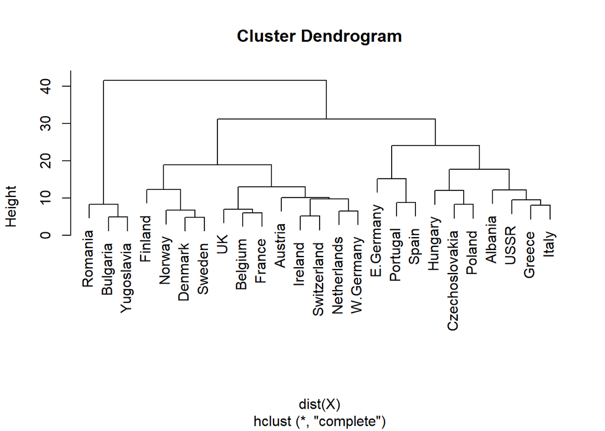

```
## [1] "0.017 secs to complete method ... complete"
```

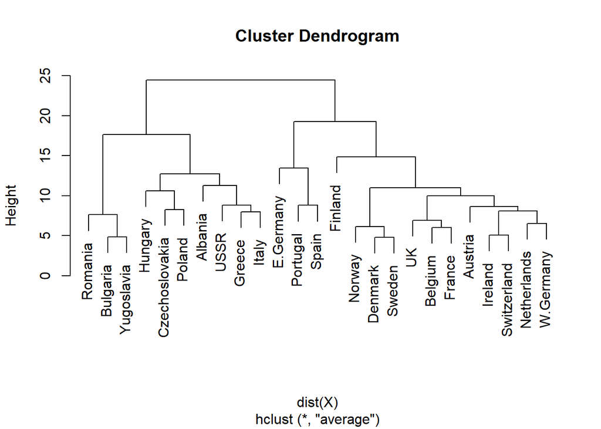

```
## [1] "0.044 secs to complete method ... average"
```

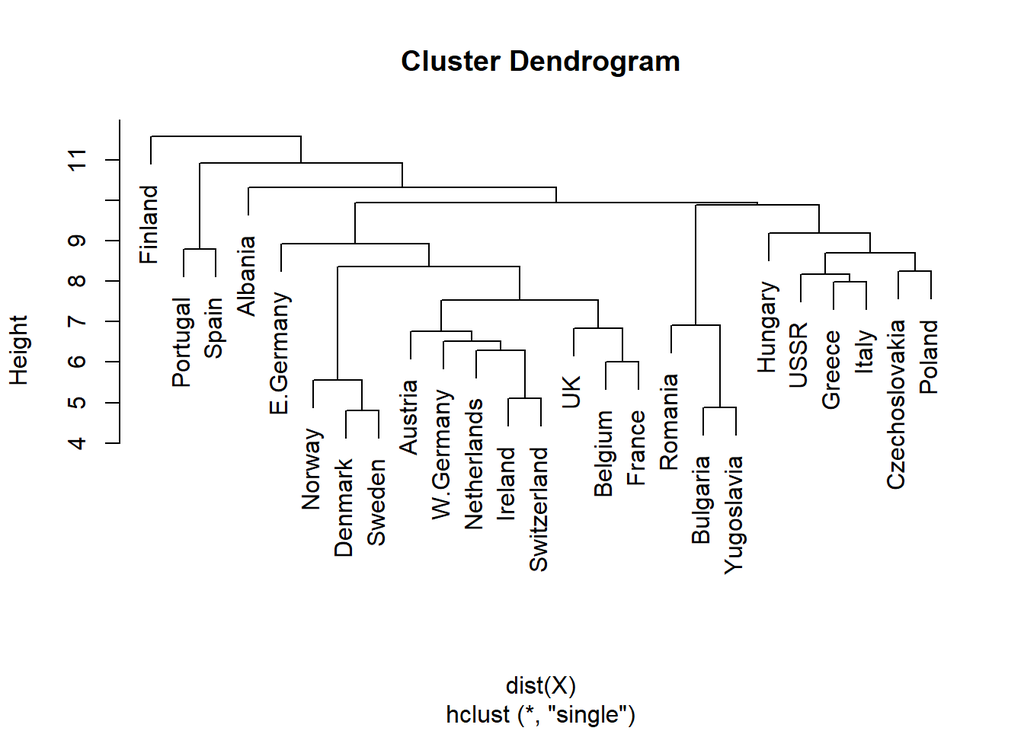

```
## [1] "0.043 secs to complete method ... single"
```

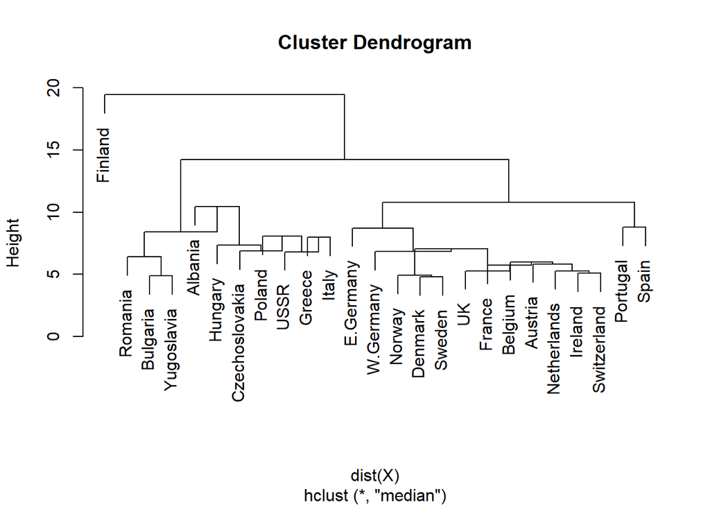

```
## [1] "0.046 secs to complete method ... median"
```

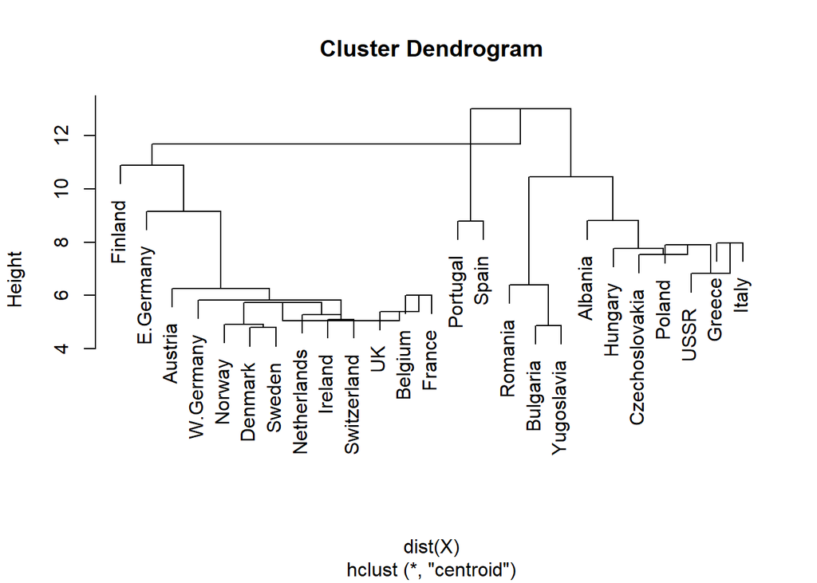

```
## [1] "0.041 secs to complete method ... centroid"
```

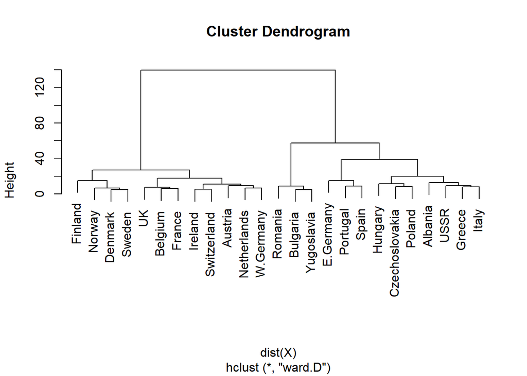

```
## [1] "0.043 secs to complete method ... ward.D"
```

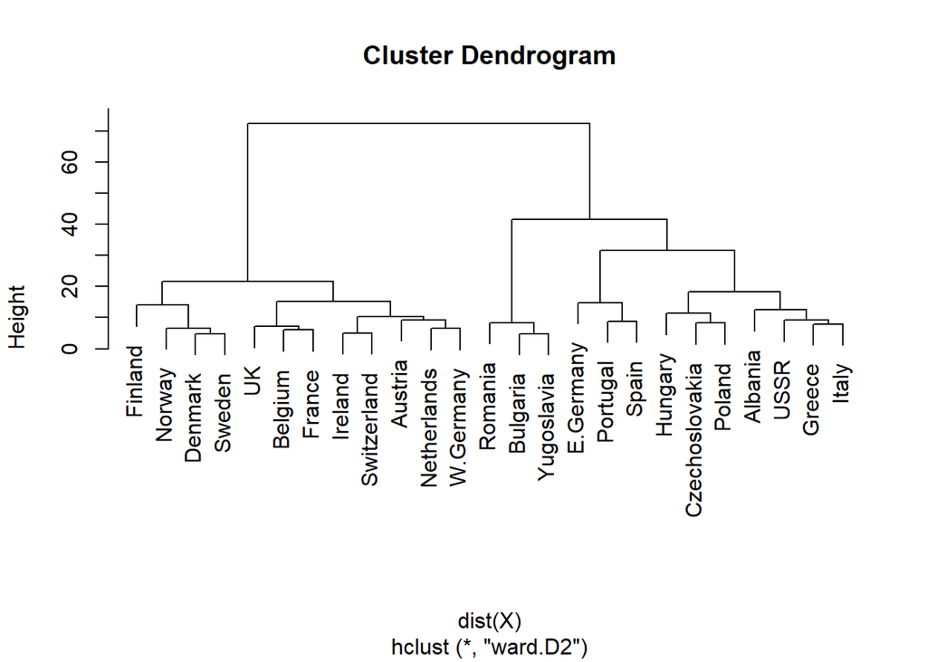

```
## [1] "0.044 secs to complete method ... ward.D2"
```

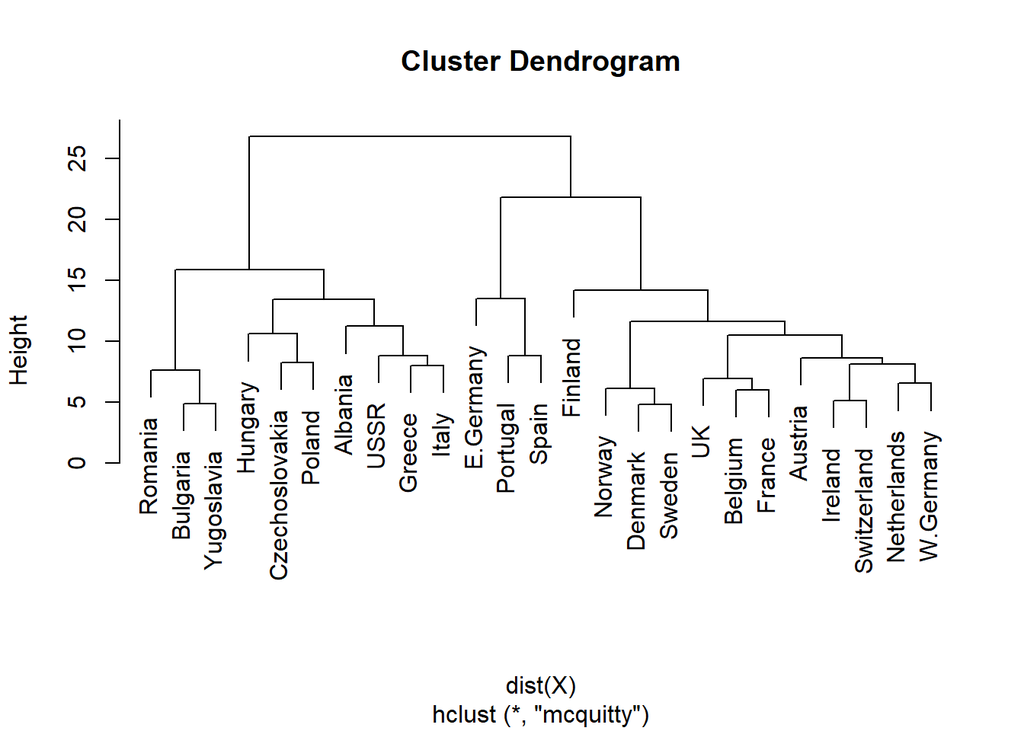

```
## [1] "0.039 secs to complete method ... mcquitty"
```

```r
# should we scale the data?
X = removeColumnsFromDataFrame(protein,"Country");
rownames(X) = protein$Country;

methods = c("complete", "average", "single", "median", "centroid", "ward.D", "ward.D2", "mcquitty");

for(method in methods)
  {
  time.start = Sys.time();
      X.hclust = hclust( dist(X), method=method);
  plot(X.hclust);
  time.end = Sys.time();
  elapse = sprintf("%.3f", as.numeric(time.end) - as.numeric(time.start));
  print(paste0(elapse, " secs to complete method ... ", method));
  }
```

From above, would you conclude that Romania, Bulgaria, and Yugoslavia have similar `protein-eating` habits? Any other clusters you can easily identify? We call this unit `explorator data analysis` for a reason. We try to visualize the data and articulate some initial findings.

```
## Bootstrap (r = 0.44)... Done.
## Bootstrap (r = 0.56)... Done.
## Bootstrap (r = 0.67)... Done.
## Bootstrap (r = 0.78)... Done.
## Bootstrap (r = 0.89)... Done.
## Bootstrap (r = 1.0)... Done.
## Bootstrap (r = 1.11)... Done.
## Bootstrap (r = 1.22)... Done.
## Bootstrap (r = 1.33)... Done.
```

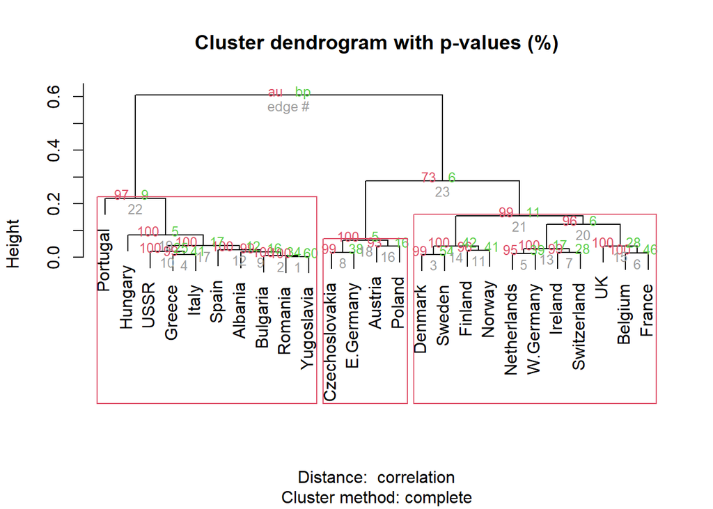

```
## [1] "17.199 secs to complete method ... complete"
## Bootstrap (r = 0.44)... Done.
## Bootstrap (r = 0.56)... Done.
## Bootstrap (r = 0.67)... Done.
## Bootstrap (r = 0.78)... Done.
## Bootstrap (r = 0.89)... Done.
## Bootstrap (r = 1.0)... Done.
## Bootstrap (r = 1.11)... Done.
## Bootstrap (r = 1.22)... Done.
## Bootstrap (r = 1.33)... Done.
```

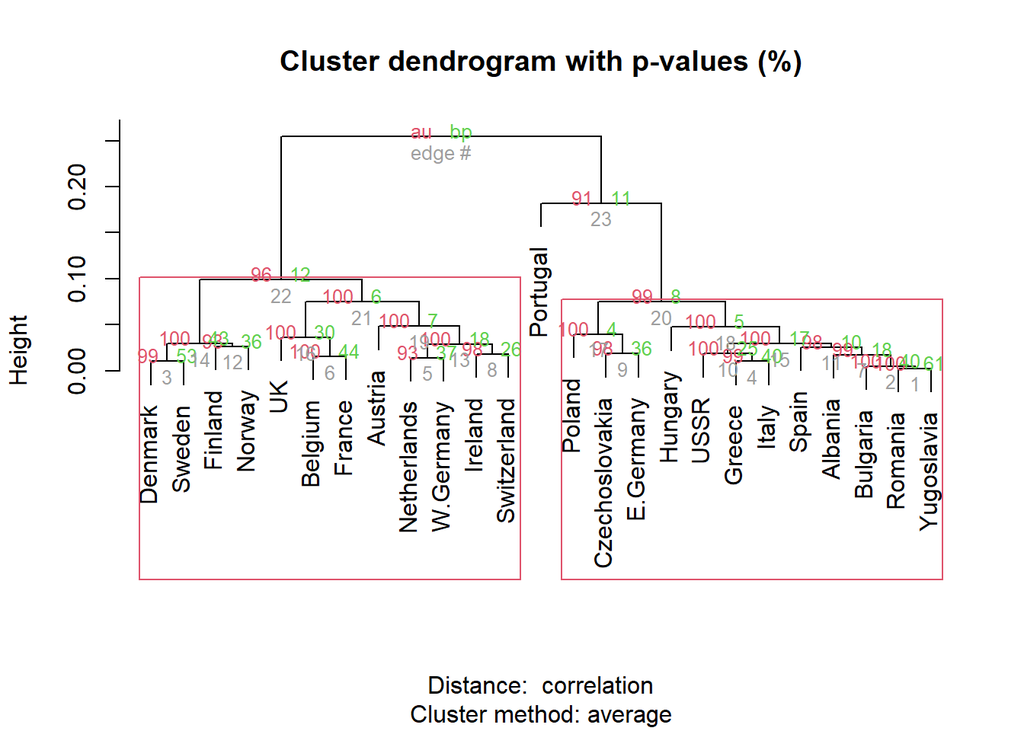

```
## [1] "14.950 secs to complete method ... average"
## Bootstrap (r = 0.44)... Done.
## Bootstrap (r = 0.56)... Done.
## Bootstrap (r = 0.67)... Done.
## Bootstrap (r = 0.78)... Done.
## Bootstrap (r = 0.89)... Done.
## Bootstrap (r = 1.0)... Done.
## Bootstrap (r = 1.11)... Done.
## Bootstrap (r = 1.22)... Done.
## Bootstrap (r = 1.33)... Done.
```

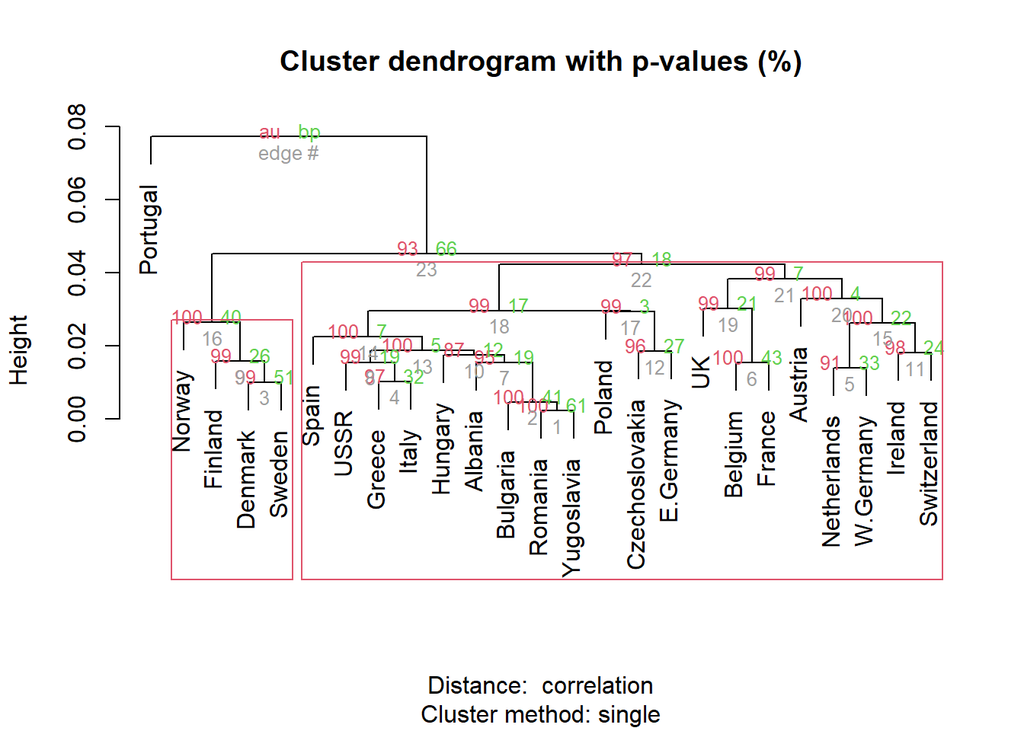

```
## [1] "16.027 secs to complete method ... single"
## Bootstrap (r = 0.44)... Done.
## Bootstrap (r = 0.56)... Done.
## Bootstrap (r = 0.67)... Done.
## Bootstrap (r = 0.78)... Done.
## Bootstrap (r = 0.89)... Done.
## Bootstrap (r = 1.0)... Done.
## Bootstrap (r = 1.11)... Done.
## Bootstrap (r = 1.22)... Done.
## Bootstrap (r = 1.33)... Done.
```

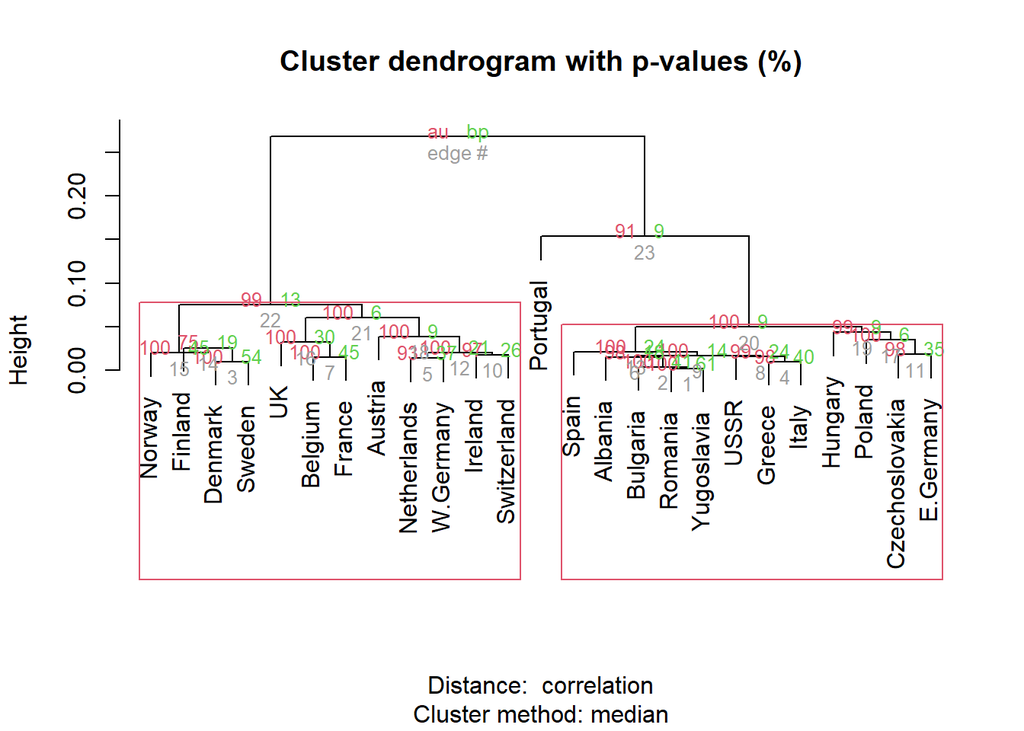

```
## [1] "15.120 secs to complete method ... median"
## Bootstrap (r = 0.44)... Done.
## Bootstrap (r = 0.56)... Done.
## Bootstrap (r = 0.67)... Done.
## Bootstrap (r = 0.78)... Done.
## Bootstrap (r = 0.89)... Done.
## Bootstrap (r = 1.0)... Done.
## Bootstrap (r = 1.11)... Done.
## Bootstrap (r = 1.22)... Done.
## Bootstrap (r = 1.33)... Done.
```

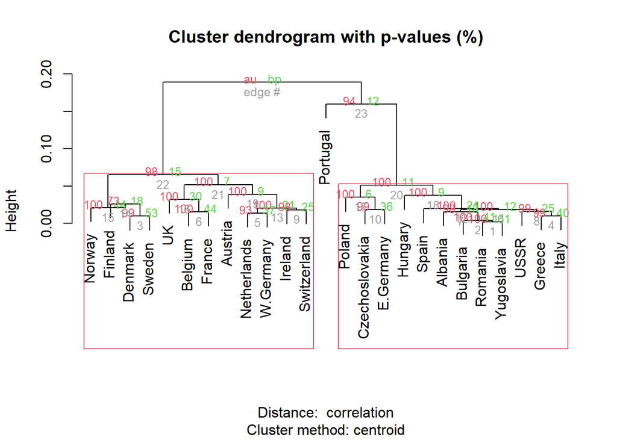

```
## [1] "14.989 secs to complete method ... centroid"
## Bootstrap (r = 0.44)... Done.
## Bootstrap (r = 0.56)... Done.
## Bootstrap (r = 0.67)... Done.
## Bootstrap (r = 0.78)... Done.
## Bootstrap (r = 0.89)... Done.
## Bootstrap (r = 1.0)... Done.
## Bootstrap (r = 1.11)... Done.
## Bootstrap (r = 1.22)... Done.
## Bootstrap (r = 1.33)... Done.
```

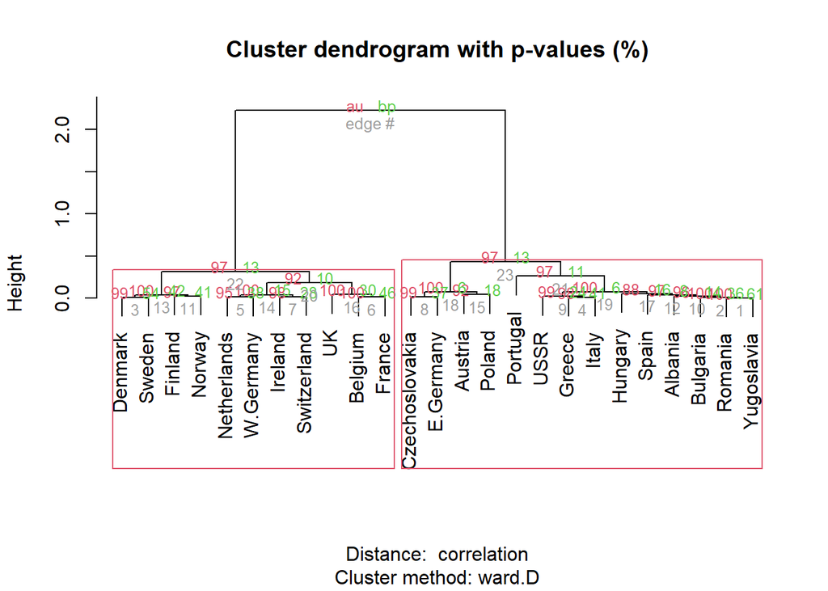

```
## [1] "14.820 secs to complete method ... ward.D"
## Bootstrap (r = 0.44)... Done.
## Bootstrap (r = 0.56)... Done.
## Bootstrap (r = 0.67)... Done.
## Bootstrap (r = 0.78)... Done.
## Bootstrap (r = 0.89)... Done.
## Bootstrap (r = 1.0)... Done.
## Bootstrap (r = 1.11)... Done.
## Bootstrap (r = 1.22)... Done.
## Bootstrap (r = 1.33)... Done.
```

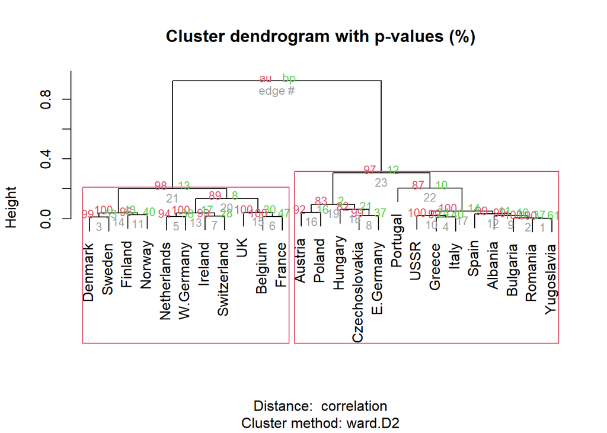

```
## [1] "14.994 secs to complete method ... ward.D2"
## Bootstrap (r = 0.44)... Done.
## Bootstrap (r = 0.56)... Done.
## Bootstrap (r = 0.67)... Done.
## Bootstrap (r = 0.78)... Done.
## Bootstrap (r = 0.89)... Done.
## Bootstrap (r = 1.0)... Done.
## Bootstrap (r = 1.11)... Done.
## Bootstrap (r = 1.22)... Done.
## Bootstrap (r = 1.33)... Done.
```

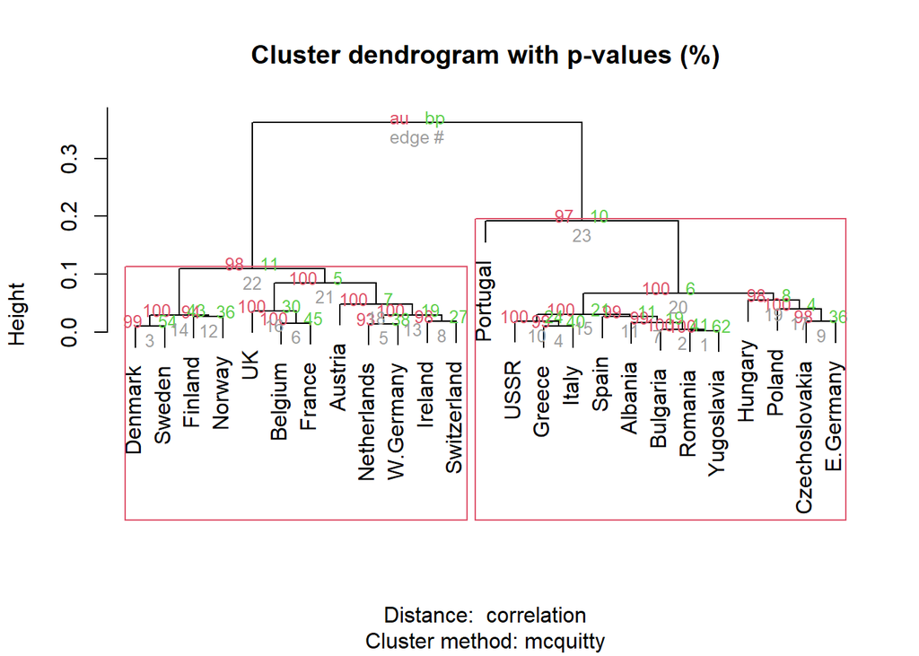

```
## [1] "15.500 secs to complete method ... mcquitty"
```

```r
library(pvclust);  # install.packages("pvclust", dependencies=TRUE);

# pvclust uses "bootstrapping" to analyze the stability of the hclust.  For some reason, you have to transpose the data inputs to still "cluster" by country.

# nboot=1000 ... is it 1000 times slower?
# r = seq(0.5,1.4,by=.1); # what proportion of the data should be used in the bootstrap


for(method in methods)
  {
  time.start = Sys.time();
      X.pvclust = pvclust ( protein.t, method.hclust=method);
  plot(X.pvclust);
      pvrect(X.pvclust);
  time.end = Sys.time();
  elapse = sprintf("%.3f", as.numeric(time.end) - as.numeric(time.start));
  print(paste0(elapse, " secs to complete method ... ", method));
  }
```

```r
# this will take awhile to Knit ...
```

The red box around certain dendograms represents a `best-guess` final answer. In general, it appears there are two clusters on countries. So although the individual `hclust` dendograms suggested maybe more refined cluster.

The red numbers are called `au p-values` … Would you conclude that Portugal appears to be an odd-country out?

#### 1.1.2.1 Repeat above with a scaled X

For the above examples, try scaling the data first. That is, use `Xs = scale(X);`

Make some comments about the differences. Before proceeding, make a decision on whether or not you plan on scaling the data.

#### 1.1.2.2 Repeat above `hclust` and `pvclust` where the aggregation is on food types, not countries

Now, you copy those two chunks and use the opposite data forms. Where `protein` was used, you should use `protein.t` and vice versa.

Are you using `X` or `Xs` to perform this analysis.

## 1.2 Dataset `measure` (e.g., Project 1)

Would you want to cluster the “participants” or the “body parts”? Why?

Maybe do some `sandbox play` with your toy dataset. We will get you the larger dataset soon.

## 1.3 Dataset `cars`

```r
car.file = paste0(example.datasets.path,"MBA_CAR_ATTRIB.txt");

mba.cars = na.omit(read.table(car.file,na.strings='.'));

myAttributes = c("Exciting", "Dependable", "Luxurious",
                  "Outdoorsy", "Powerful", "Stylish",
                  "Comfortable", "Rugged", "Fun",
                  "Safe", "Performance", "Family",
                  "Versatile", "Sports", "Status",
                  "Practical");

car.ids = mba.cars$V1;

cars = mba.cars[,3:18];

colnames(cars) = myAttributes;
rownames(cars) = car.ids;

head(cars);
```

|  | Exciting | Dependable | Luxurious | Outdoorsy | Powerful | Stylish | Comfortable | Rugged | Fun | Safe | Performance | Family | Versatile | Sports | Status | Practical |
| --- | --- | --- | --- | --- | --- | --- | --- | --- | --- | --- | --- | --- | --- | --- | --- | --- |
| 1001 | 3 | 5 | 5 | 1 | 3 | 4 | 5 | 1 | 3 | 5 | 3 | 5 | 3 | 1 | 4 | 3 |
| 1002 | 2 | 3 | 2 | 1 | 2 | 1 | 2 | 2 | 2 | 3 | 2 | 4 | 3 | 1 | 1 | 4 |
| 1004 | 3 | 2 | 3 | 1 | 2 | 3 | 3 | 1 | 3 | 2 | 3 | 2 | 2 | 3 | 4 | 2 |
| 1005 | 5 | 4 | 4 | 2 | 3 | 5 | 3 | 3 | 5 | 4 | 5 | 1 | 2 | 5 | 5 | 2 |
| 1006 | 2 | 4 | 3 | 3 | 2 | 2 | 4 | 1 | 2 | 5 | 2 | 5 | 4 | 1 | 3 | 4 |
| 1007 | 3 | 2 | 3 | 1 | 3 | 4 | 2 | 2 | 2 | 3 | 2 | 2 | 2 | 4 | 1 | 2 |

```r
# should we scale the data ... ?
```

Use `hclust` and `pvclust` to aggregate `myAttributes`